# Lab2

Daniela Ramírez, Adrián Gonzáles y José Ordoñez

2026-02-23

```r
library(tidyverse)
library(lubridate)
library(cluster)
library(factoextra)
library(hopkins)
library(NbClust)
library(psych)
```

```r
library(FactoMineR)
library(fpc)
library(factoextra)
library(corrplot)
library(PCAmixdata)
library(paran)
library(arules)
library(arulesViz)
library(Rtsne)
```

```r
movies <- read.csv("movies_2026.csv", stringsAsFactors = F)

str(movies)
```

```
## 'data.frame':    19883 obs. of  28 variables:
##  $ id                       : int  1627085 1626914 1626898 1626808 1626678 1626234 1626010 1625551 1625043 1624457 ...
##  $ budget                   : num  0 0 0 0 0 1 0 0 0 0 ...
##  $ genres                   : chr  "Drama|Crime" "Animation" "Animation" "Thriller|Mystery|Documentary" ...
##  $ homePage                 : chr  "" "" "" "" ...
##  $ productionCompany        : chr  "" "" "" "" ...
##  $ productionCompanyCountry : chr  "" "" "" "" ...
##  $ productionCountry        : chr  "" "" "" "" ...
##  $ revenue                  : num  0 0 0 0 0 1 0 0 0 0 ...
##  $ runtime                  : int  95 3 2 5 12 14 39 90 96 106 ...
##  $ video                    : logi  FALSE FALSE FALSE FALSE FALSE FALSE ...
##  $ director                 : chr  "Javad Hakami" "Kimmy Gatewood" "Kimmy Gatewood" "Felipe Roldán" ...
##  $ actors                   : chr  "Mohsen Ghasabian|Aida Mahiani|Mehran Ghafourian|Payam Ahmadinia|Masoud Karamati|Roya Javidnia|Nasim Adabi|Siavash Cheraghipour" "Kameron Jackson|Laura Weaving|sara weaving|Bertha Williams" "Cedric Mitchell|Cajun mills|Laura Williams" "Tomás Tuchsznajder|Matias …
##  $ actorsPopularity         : chr  "0.3453|0.1664|0.9684|0.3437|0.3713|0.2437|0.2796|0.2639" "0|0.0071|0|0" "0.0193|0|0.0143" "0|0|0|0|0|0|0" ...
##  $ actorsCharacter          : chr  "|||||||" "Prince Charming|Evil Stepmother|Fairy Godmother|Cinderella" "Aladdin|Jafar|Jasmine" "||||||" ...
##  $ originalTitle            : chr  "غوطه ور" "Cinderella" "Aladdin" "EL ANILLO Y EL DECK" ...
##  $ title                    : chr  "Immersed" "Cinderella" "Aladdin" "THE RING AND THE DECK" ...
##  $ originalLanguage         : chr  "fa" "en" "en" "es" ...
##  $ popularity               : num  0.0357 0.0357 0.0214 0.0429 0.0379 ...
##  $ releaseDate              : chr  "2026-02-01" "2026-02-01" "2026-02-01" "2026-02-01" ...
##  $ voteAvg                  : num  0 0 0 0 0 0 0 0 0 0 ...
##  $ voteCount                : int  0 0 0 0 0 0 0 0 0 0 ...
##  $ genresAmount             : int  2 1 1 3 1 1 1 1 3 1 ...
##  $ productionCoAmount       : int  0 0 0 0 0 0 0 0 0 0 ...
##  $ productionCountriesAmount: int  0 0 0 0 0 0 0 1 1 0 ...
##  $ actorsAmount             : int  8 4 3 7 3 3 5 4 5 5 ...
##  $ castWomenAmount          : int  2 0 0 0 0 0 0 3 1 2 ...
##  $ castMenAmount            : int  5 0 0 0 0 0 3 0 3 3 ...
##  $ releaseYear              : int  2026 2026 2026 2026 2026 2026 2026 2026 2026 2026 ...
```

```r
#Preprocesamiento de datos

movies_clust <- movies %>%
  dplyr::select(-id,
         -originalTitle,
         -title,
         -homePage,
         -director,
         -actors,
         -actorsCharacter,
         -productionCompany,
         -productionCompanyCountry,
         -productionCountry,
         -releaseDate)

# Eliminar NA
movies_clust <- movies_clust %>%
  drop_na()

# Seleccionar variables numéricas
movies_num <- movies_clust %>%
  dplyr::select(where(is.numeric))

# Escalar datos
movies_scaled <- scale(movies_num)
```

```r
set.seed(123)

# Tomar muestra de 1000 observaciones
sample_index <- sample(1:nrow(movies_scaled), 1000)

movies_sample <- movies_scaled[sample_index, ]

# Hopkins
hopkins_stat <- hopkins::hopkins(
  X = movies_sample,
  m = floor(0.1 * nrow(movies_sample))
)

hopkins_stat
```

```
## [1] 1
```

El estadístico de Hopkins obtuvo un valor de 0.999999999997353.

Un valor cercano a 1 indica fuerte tendencia al agrupamiento, mientras que valores cercanos a 0.5 indican distribución aleatoria.

Dado que el valor obtenido es mayor a 0.9, existe evidencia de que los datos presentan estructura de agrupamiento y por lo tanto es adecuado aplicar algoritmos de clustering.

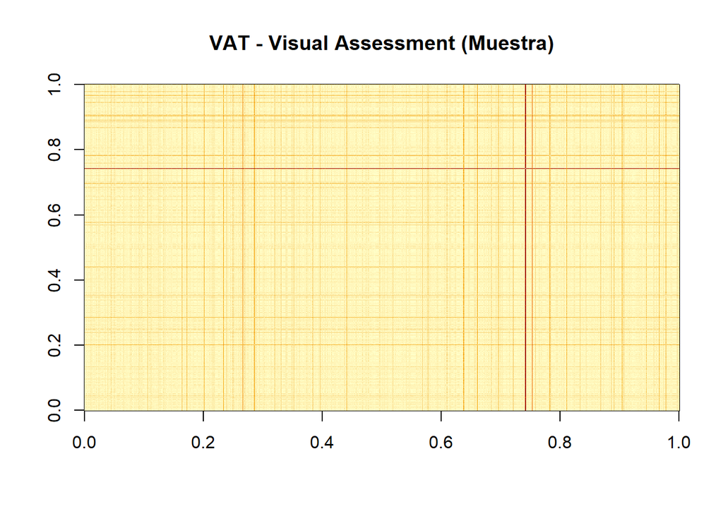

```r
# VAT con muestra
dist_matrix_sample <- dist(movies_sample)

image(as.matrix(dist_matrix_sample),
      main = "VAT - Visual Assessment (Muestra)")
```

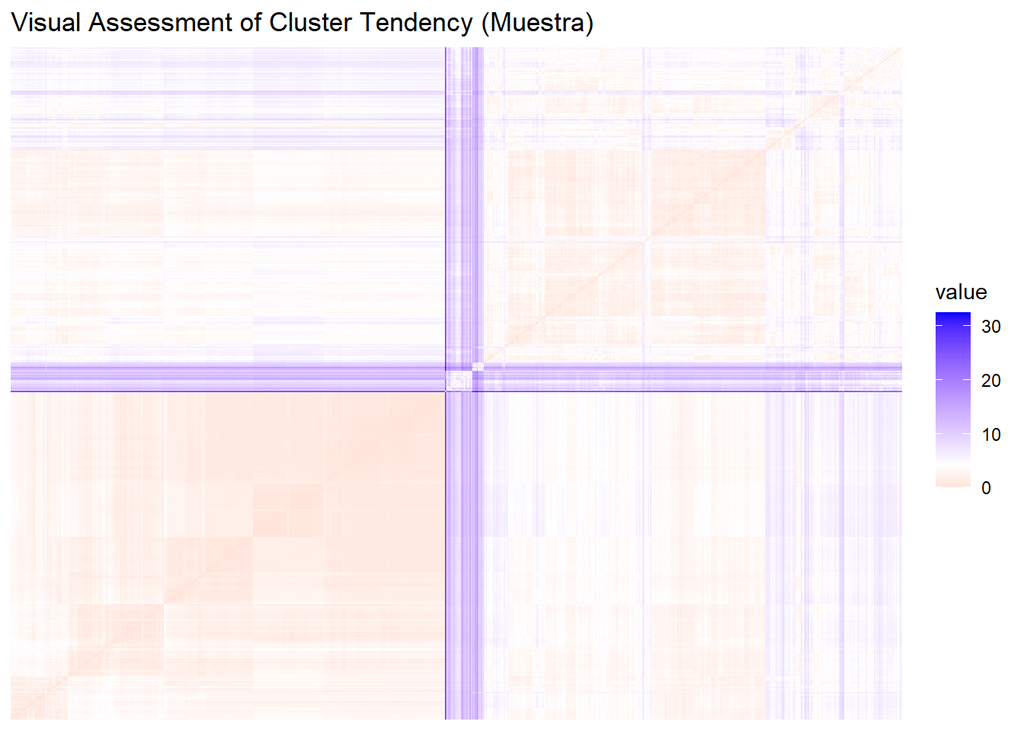

```r
fviz_dist(dist_matrix_sample,
          show_labels = FALSE) +
  ggtitle("Visual Assessment of Cluster Tendency (Muestra)")
```

La evaluación visual de la matriz de distancias muestra variaciones en la intensidad del color, lo cual sugiere cierta estructura en los datos. No se observan bloques completamente definidos, lo que indica que los grupos no están perfectamente separados, pero sí existe tendencia al agrupamiento. Este resultado es consistente con el estadístico de Hopkins obtenido previamente, el cual confirmó la presencia de estructura no aleatoria en los datos.

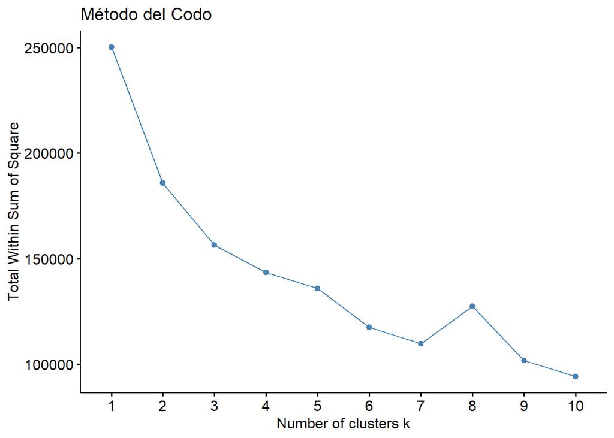

```r
#Codo

fviz_nbclust(movies_scaled, kmeans, method = "wss") +
  ggtitle("Método del Codo")
```

```r
# Ajustar según gráfica
k_opt <- 3
```

En la gráfica del método del codo se observa un punto de inflexión claro en k = 3, a partir del cual la reducción en la suma de cuadrados intra-cluster comienza a disminuir de forma más gradual. Por esta razón se selecciona k = 3 como número óptimo de clusters, ya que representa un equilibrio adecuado entre reducción de variabilidad interna y simplicidad del modelo.

```r
#k-means

set.seed(123)

kmeans_model <- kmeans(
  movies_scaled,
  centers = k_opt,
  nstart = 25
)

movies_clust$kmeans_cluster <- kmeans_model$cluster
```

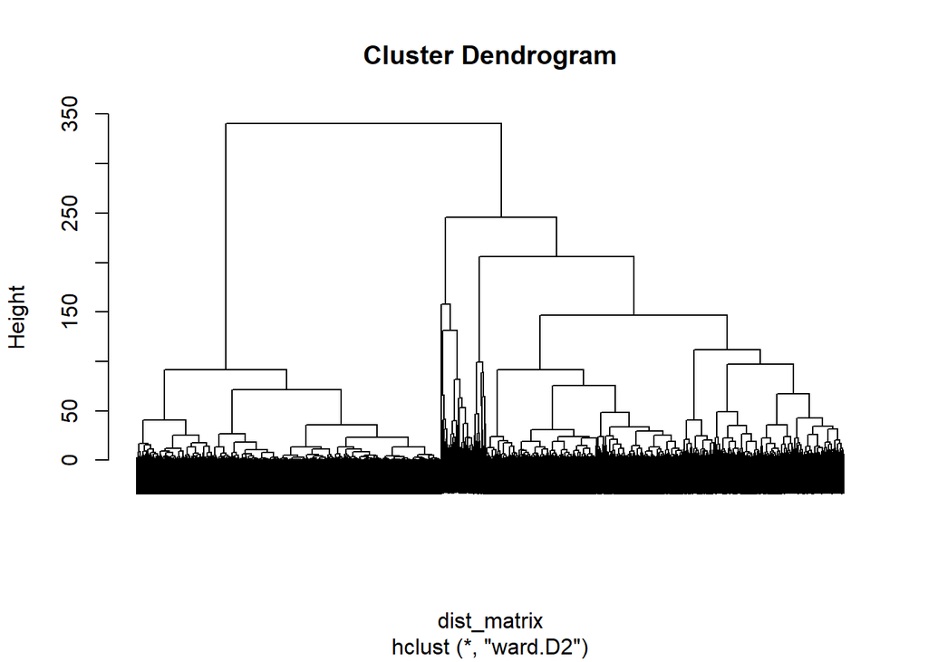

```r
#Clustering jerárquico

dist_matrix <- dist(movies_scaled)

hc_model <- hclust(dist_matrix, method = "ward.D2")

plot(hc_model, labels = FALSE)
```

```r
hc_clusters <- cutree(hc_model, k = k_opt)

movies_clust$hc_cluster <- hc_clusters
```

```
##   cluster size ave.sil.width
## 1       1  918          0.02
## 2       2 8775          0.15
## 3       3 9547          0.58
```

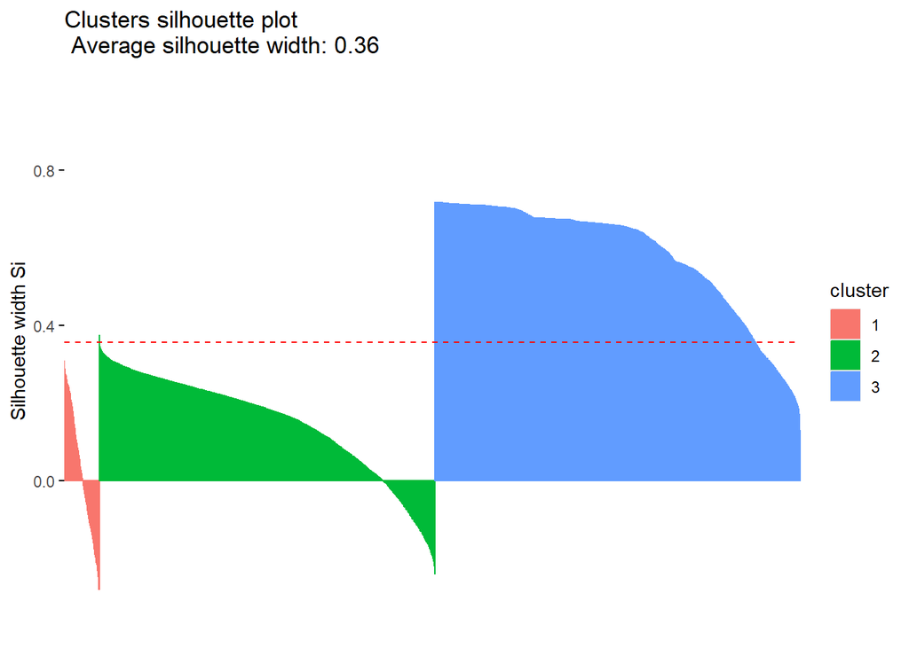

```r
#Silueta

# K-means
sil_kmeans <- silhouette(kmeans_model$cluster, dist_matrix)

fviz_silhouette(sil_kmeans)
```

```r
mean(sil_kmeans[, 3])
```

```
## [1] 0.357122
```

```
##   cluster  size ave.sil.width
## 1       1  8280          0.64
## 2       2 10080          0.10
## 3       3   880          0.01
```

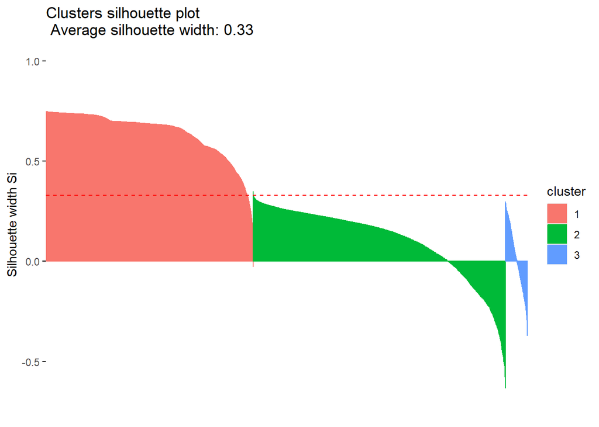

```r
# Jerárquico
sil_hc <- silhouette(hc_clusters, dist_matrix)

fviz_silhouette(sil_hc)
```

```r
mean(sil_hc[, 3])
```

```
## [1] 0.330042
```

El promedio del índice de silueta para K-means fue 0.357, mientras que para el clustering jerárquico fue 0.330.

Aunque ambos métodos presentan una separación moderada entre grupos, K-means muestra un mejor desempeño global según el promedio de silueta.

Por esta razón se selecciona K-means como el método definitivo para la interpretación de los clusters.

```r
#Interpretación de datos
movies_clust %>%
  group_by(kmeans_cluster) %>%
  summarise(across(where(is.numeric), mean))
```

| kmeans_cluster | budget | revenue | runtime | popularity | voteAvg | voteCount | genresAmount | productionCoAmount | productionCountriesAmount | actorsAmount | castWomenAmount | castMenAmount | releaseYear | hc_cluster |
| --- | --- | --- | --- | --- | --- | --- | --- | --- | --- | --- | --- | --- | --- | --- |
| 1 | 88989976.61 | 327890188.46 | 121.19499 | 148.181600 | 6.8748584 | 6126.579521 | 2.990196 | 3.9531590 | 1.6786492 | 60.783224 | 14.4313725 | 70.84423 | 2007.515 | 2.827887 |
| 2 | 9374627.15 | 20317448.05 | 100.58028 | 35.672743 | 6.4488825 | 685.924786 | 2.581311 | 3.0490028 | 1.7354986 | 23.185527 | 6.1774359 | 16002.28080 | 2009.085 | 2.008319 |
| 3 | 12656.81 | 12010.46 | 27.44223 | 1.331198 | 0.9655268 | 1.557243 | 1.229706 | 0.6619881 | 0.6878601 | 3.592228 | 0.5100031 | 903.58343 | 2025.037 | 1.137635 |

```r
# Géneros
movies_clust %>%
  group_by(kmeans_cluster, genres) %>%
  summarise(n = n()) %>%
  arrange(kmeans_cluster, desc(n))
```

| kmeans_cluster | genres | n |
| --- | --- | --- |
| 1 | Comedy | 29 |
| 1 | Comedy\|Romance | 29 |
| 1 | Drama | 21 |
| 1 | Action\|Adventure\|Science Fiction | 20 |
| 1 | Action\|Thriller | 16 |
| 1 | Action\|Adventure\|Fantasy | 15 |
| 1 | Drama\|Romance | 13 |
| 1 | Comedy\|Drama | 11 |
| 1 | Action\|Thriller\|Science Fiction | 10 |
| 1 | Adventure\|Action\|Science Fiction | 10 |

[output cut: 3517 more lines]

```r
# Idioma original
movies_clust %>%
  group_by(kmeans_cluster, originalLanguage) %>%
  summarise(n = n()) %>%
  arrange(kmeans_cluster, desc(n))
```

| kmeans_cluster | originalLanguage | n |
| --- | --- | --- |
| 1 | en | 902 |
| 1 | zh | 6 |
| 1 | fr | 2 |
| 1 | it | 2 |
| 1 | ja | 2 |
| 1 | ko | 2 |
| 1 | cn | 1 |
| 1 | es | 1 |
| 2 | en | 6485 |
| 2 | ja | 606 |

[output cut: 144 more lines]

## Interpretación de los Clusters (K-means)

Cluster 1: Se caracteriza por películas de alto presupuesto (≈88 millones) y altos ingresos (≈327 millones), con elevada popularidad y duración promedio de 121 minutos. Predominan producciones en idioma inglés y géneros comerciales como comedia, drama y acción/aventura. Este grupo representa películas comerciales de alto rendimiento o “blockbusters” orientadas al mercado internacional.

Cluster 2: Incluye películas de presupuesto medio (≈9 millones) y recaudación moderada (≈20 millones). Presentan menor popularidad en comparación con el Cluster 1 y mayor diversidad de idiomas, incluyendo producciones en inglés y japonés. Este grupo puede interpretarse como cine independiente o producciones regionales con alcance moderado.

Cluster 3: Está compuesto por producciones de muy bajo presupuesto y escasa recaudación, con baja duración promedio y mínima popularidad. Este segmento podría representar cortometrajes o producciones de bajo impacto comercial.

```r
datos_pca <- movies[, c(
  "budget",
  "revenue",
  "runtime",
  "popularity",
  "voteAvg",
  "voteCount",
  "genresAmount",
  "productionCoAmount",
  "productionCountriesAmount",
  "actorsAmount",
  "castWomenAmount",
  "castMenAmount"
)]
```

## Inclusión de variables categóricas en el PCA

Las variables categóricas como género, idioma original o país de producción podrían transformarse mediante técnicas como codificación one-hot (dummies) para ser incluidas en el análisis.

Sin embargo, este tipo de transformación incrementaría considerablemente la dimensionalidad del conjunto de datos y podría introducir alta dispersión y ruido, afectando la estabilidad de los componentes principales.

Dado que el objetivo del PCA es reducir dimensionalidad y sintetizar información relevante, se decidió utilizar únicamente variables numéricas, ya que estas representan directamente magnitudes financieras, de popularidad y estructura de producción.

Por lo tanto, no se consideró conveniente incluir variables categóricas transformadas en este análisis.

```r
rcor<-cor(datos_pca, use = "complete.obs")
det(rcor)
```

```
## [1] 0.004624598
```

```r
KMO(as.matrix(datos_pca))
```

```
## Kaiser-Meyer-Olkin factor adequacy
## Call: KMO(r = as.matrix(datos_pca))
## Overall MSA =  0.76
## MSA for each item =
##                    budget                   revenue                   runtime
##                      0.80                      0.70                      0.82
##                popularity                   voteAvg                 voteCount
##                      0.92                      0.78                      0.80
##              genresAmount        productionCoAmount productionCountriesAmount
##                      0.86                      0.81                      0.58
##              actorsAmount           castWomenAmount             castMenAmount
##                      0.38                      0.39                      0.48
```

Al obtener la determinante de la matriz de correlación, nos indica que las variables si están relacionadas entre si.

Utilizamos KMO para determinar si se puede utilizar análisis factorial para las combinaciones lineales de las variables. Obtuvimos 0.76 como indice, esto se encuentra entre 0.7 y 0.8, lo cual nos indica que es una adecuación muestral aceptable.

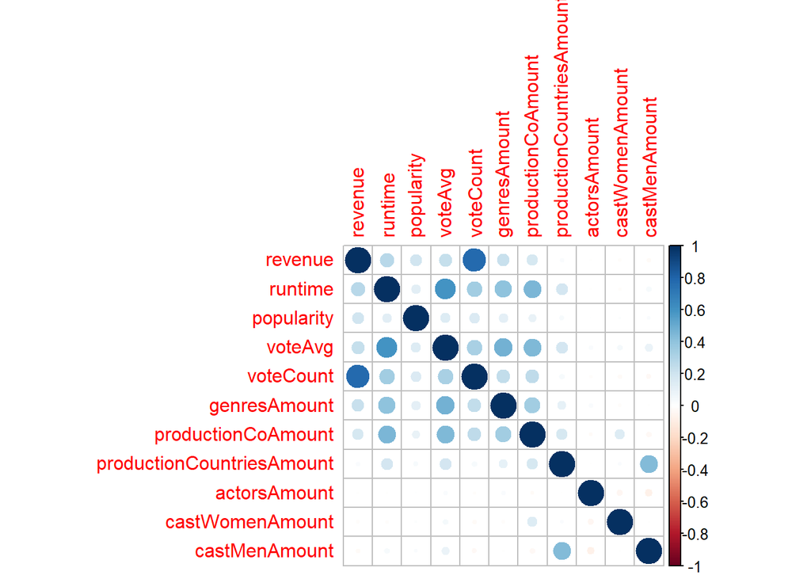

```r
matriz <- cor(datos_pca[,-1],use = "pairwise.complete.obs")
corrplot(matriz)
```

# Prueba de Esfericidad de Bartlett

```r
cortest.bartlett(matriz, n = nrow(datos_pca))
```

```
## $chisq
## [1] 50302.23
##
## $p.value
## [1] 0
##
## $df
## [1] 55
```

La prueba de Bartlett arrojó un estadístico χ² = 50302.23 con 55 grados de libertad y un p-value < 0.001. Dado que el valor p es menor a 0.05, se rechaza la hipótesis nula de que la matriz de correlación sea identidad.

Esto indica que existe correlación significativa entre las variables y, por lo tanto, es apropiado aplicar el Análisis de Componentes Principales.

# Índice KMO

```r
KMO(matriz)
```

```
## Kaiser-Meyer-Olkin factor adequacy
## Call: KMO(r = matriz)
## Overall MSA =  0.7
## MSA for each item =
##                   revenue                   runtime                popularity
##                      0.59                      0.80                      0.85
##                   voteAvg                 voteCount              genresAmount
##                      0.77                      0.62                      0.85
##        productionCoAmount productionCountriesAmount              actorsAmount
##                      0.81                      0.58                      0.38
##           castWomenAmount             castMenAmount
##                      0.39                      0.47
```

El índice KMO global fue 0.70, lo cual indica una adecuación aceptable del modelo factorial.

Aunque algunas variables presentan valores individuales bajos (principalmente las relacionadas con el elenco), el valor global sugiere que el conjunto de datos es adecuado para aplicar PCA.

# Ajustes adicionales

```r
# Convertir a numérico
datos_pca[] <- lapply(datos_pca, function(x) as.numeric(as.character(x)))

# Eliminar NA
datos_pca <- na.omit(datos_pca)

# Escalar datos
datos_scaled <- scale(datos_pca)

# Crear objeto PCA
pca <- prcomp(datos_scaled, center = TRUE, scale. = TRUE)
```

```r
summary(pca)
```

```
## Importance of components:
##                           PC1    PC2    PC3     PC4    PC5     PC6     PC7
## Standard deviation     2.1418 1.2910 1.1465 0.97692 0.8708 0.78923 0.74845
## Proportion of Variance 0.3823 0.1389 0.1095 0.07953 0.0632 0.05191 0.04668
## Cumulative Proportion  0.3823 0.5212 0.6307 0.71024 0.7734 0.82535 0.87203
##                            PC8    PC9    PC10    PC11    PC12
## Standard deviation     0.68989 0.6293 0.55585 0.43653 0.40521
## Proportion of Variance 0.03966 0.0330 0.02575 0.01588 0.01368
## Cumulative Proportion  0.91169 0.9447 0.97044 0.98632 1.00000
```

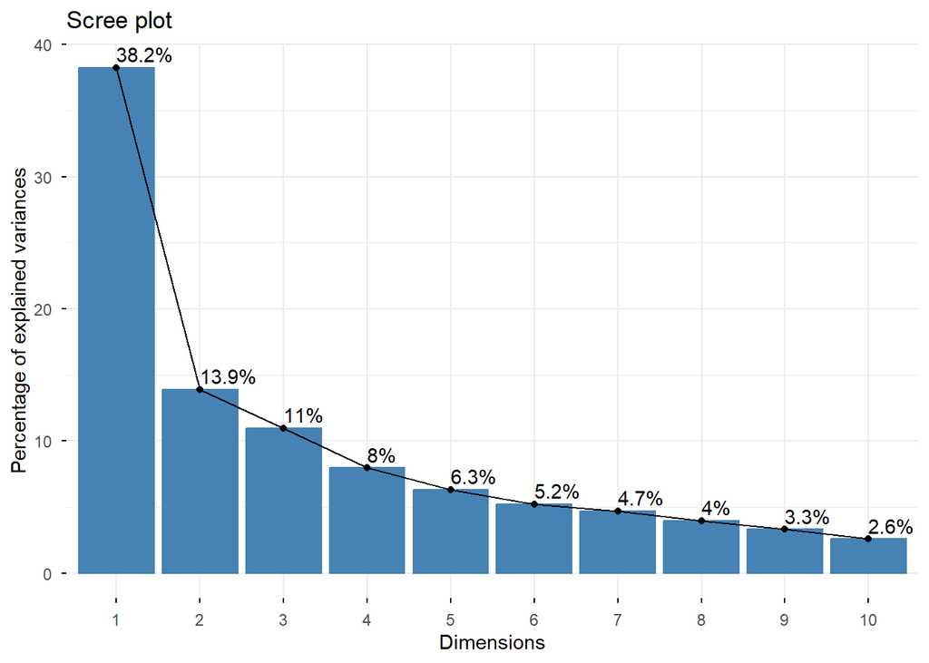

```r
fviz_eig(pca, addlabels = TRUE)
```

```r
round(pca$rotation, 3)
```

```
##                             PC1    PC2    PC3    PC4    PC5    PC6    PC7
## budget                    0.342 -0.328 -0.220 -0.026  0.168  0.093  0.057
## revenue                   0.321 -0.404 -0.302 -0.053  0.169  0.043 -0.044
## runtime                   0.333  0.251  0.167  0.012 -0.046  0.012 -0.368
## popularity                0.120 -0.070 -0.154  0.936 -0.270  0.016  0.047
## voteAvg                   0.318  0.303  0.169  0.094  0.124 -0.170 -0.355
## voteCount                 0.344 -0.325 -0.214 -0.115  0.096  0.052 -0.122
## genresAmount              0.263  0.188  0.208  0.169  0.639 -0.382  0.451
## productionCoAmount        0.283  0.227  0.238  0.034  0.120  0.750 -0.091
## productionCountriesAmount 0.093  0.462 -0.487 -0.099 -0.060  0.300  0.515
## actorsAmount              0.387 -0.022  0.130 -0.166 -0.383 -0.189  0.089
## castWomenAmount           0.357  0.094  0.080 -0.170 -0.515 -0.229  0.257
## castMenAmount             0.001  0.394 -0.612 -0.038  0.075 -0.267 -0.406
##                              PC8    PC9   PC10   PC11   PC12
## budget                     0.063 -0.235 -0.659 -0.200  0.391
## revenue                   -0.093  0.017 -0.006  0.469 -0.615
## runtime                   -0.425 -0.674  0.149  0.056  0.027
## popularity                 0.022  0.002  0.060 -0.030  0.000
## voteAvg                   -0.319  0.625 -0.327  0.002 -0.007
## voteCount                 -0.112  0.263  0.635 -0.220  0.397
## genresAmount               0.167 -0.112  0.162  0.010 -0.010
## productionCoAmount         0.458  0.068  0.055  0.079 -0.037
## productionCountriesAmount -0.392  0.058 -0.005 -0.108 -0.061
## actorsAmount               0.213 -0.015  0.001 -0.604 -0.451
## castWomenAmount            0.187  0.058 -0.003  0.552  0.319
## castMenAmount              0.469 -0.081  0.034  0.004  0.006
```

El análisis muestra que:

La primera componente explica 38.23% de la varianza.

Las primeras cuatro componentes explican aproximadamente 71% de la variabilidad total.

Por lo tanto, se seleccionan 4 componentes principales, ya que permiten reducir la dimensionalidad manteniendo la mayor parte de la información del conjunto de datos.

Las cargas factoriales indican que:

### Componente Principal 1 (PC1)

PC1 presenta cargas altas y positivas en variables como budget, revenue, voteCount y actorsAmount.

Esto indica que esta componente representa una dimensión asociada al impacto comercial y escala de producción.

### Componente Principal 2 (PC2)

PC2 muestra asociación con variables como productionCountriesAmount y productionCoAmount, lo que sugiere una dimensión relacionada con la complejidad e internacionalización de la producción.

Esta componente podría interpretarse como una medida del grado de colaboración internacional en la película.

### Componente Principal 3 (PC3)

Esta dimensión permite diferenciar producciones según tamaño y composición del elenco.

### Componente Principal 4 (PC4)

PC4 está fuertemente influenciada por la variable popularity, representando una dimensión más asociada a percepción pública y tendencia mediática que a magnitudes financieras directas.

PCA es una técnica adecuada para sintetizar la información del dataset.

## 2. Reglas de Asociación

```r
# Preparación para reglas de asociación

#La que se usó antes de saber si valía la pena eliminar variables frecuentes

movies_rules <- movies %>%
  dplyr::select(
    genres,
    originalLanguage,
    productionCountry,
    budget,
    revenue,
    popularity,
    runtime,
    voteAvg,
    actorsAmount
  ) %>%
  filter(budget > 0,
         revenue > 0) %>%
  drop_na()
```

Se eliminaron películas con presupuesto y recaudación igual a cero, ya que representaban valores faltantes o producciones sin información financiera válida, lo que afectaba la discretización y generación de reglas.

```r
movies_rules_refined <- movies_rules %>%
  dplyr::select(-originalLanguage, -productionCountry)

movies_trans_refined <- as(movies_rules_refined, "transactions")
rules_refined <- apriori(
  movies_trans_refined,
  parameter = list(
    supp = 0.03,
    conf = 0.8,
    minlen = 2
  )
)
```

```
## Apriori
##
## Parameter specification:
##  confidence minval smax arem  aval originalSupport maxtime support minlen
##         0.8    0.1    1 none FALSE            TRUE       5    0.03      2
##  maxlen target  ext
##      10  rules TRUE
##
## Algorithmic control:
##  filter tree heap memopt load sort verbose
##     0.1 TRUE TRUE  FALSE TRUE    2    TRUE
##
## Absolute minimum support count: 135
##
## set item appearances ...[0 item(s)] done [0.00s].
## set transactions ...[1334 item(s), 4502 transaction(s)] done [0.01s].
## sorting and recoding items ... [20 item(s)] done [0.00s].
## creating transaction tree ... done [0.00s].
## checking subsets of size 1 2 3 4 5 6 done [0.00s].
## writing ... [44 rule(s)] done [0.00s].
## creating S4 object  ... done [0.00s].
```

```r
summary(rules_refined)
```

```
## set of 44 rules
##
## rule length distribution (lhs + rhs):sizes
##  3  4  5
##  4 24 16
##
##    Min. 1st Qu.  Median    Mean 3rd Qu.    Max.
##   3.000   4.000   4.000   4.273   5.000   5.000
##
## summary of quality measures:
##     support          confidence        coverage            lift
##  Min.   :0.03021   Min.   :0.8000   Min.   :0.03487   Min.   :2.399
##  1st Qu.:0.03821   1st Qu.:0.8180   1st Qu.:0.04420   1st Qu.:2.449
##  Median :0.05087   Median :0.8434   Median :0.05986   Median :2.526
##  Mean   :0.05437   Mean   :0.8518   Mean   :0.06404   Mean   :2.555
##  3rd Qu.:0.06003   3rd Qu.:0.8773   3rd Qu.:0.07308   3rd Qu.:2.631
##  Max.   :0.15104   Max.   :0.9709   Max.   :0.17703   Max.   :2.912
##      count
##  Min.   :136.0
##  1st Qu.:172.0
##  Median :229.0
##  Mean   :244.8
##  3rd Qu.:270.2
##  Max.   :680.0
##
## mining info:
##                  data ntransactions support confidence
##  movies_trans_refined          4502    0.03        0.8
##                                                                                         call
##  apriori(data = movies_trans_refined, parameter = list(supp = 0.03, conf = 0.8, minlen = 2))
```

```r
inspect(head(sort(rules_refined, by = "lift"), 10))
```

```
##      lhs                              rhs                              support confidence   coverage     lift count
## [1]  {budget=[1,1.3e+07),
##       popularity=[0,18.2),
##       voteAvg=[0,6.2),
##       actorsAmount=[0,24)}         => {revenue=[1,2.54e+07)}        0.03709462  0.9709302 0.03820524 2.912144   167
## [2]  {budget=[1,1.3e+07),
##       popularity=[0,18.2),
##       runtime=[0,99),
##       actorsAmount=[0,24)}         => {revenue=[1,2.54e+07)}        0.05086628  0.9423868 0.05397601 2.826533   229
## [3]  {budget=[1,1.3e+07),
##       popularity=[0,18.2),
##       runtime=[0,99),
##       voteAvg=[0,6.2)}             => {revenue=[1,2.54e+07)}        0.03842737  0.9402174 0.04087072 2.820026   173
## [4]  {budget=[3.9e+07,3.8e+08],
##       popularity=[36.8,1.15e+04],
##       voteAvg=[7,10],
##       actorsAmount=[42,6.68e+05]}  => {revenue=[1.01e+08,2.85e+09]} 0.03842737  0.9351351 0.04109285 2.804782   173
## [5]  {budget=[1,1.3e+07),
##       popularity=[0,18.2),
##       voteAvg=[0,6.2)}             => {revenue=[1,2.54e+07)}        0.05042203  0.9265306 0.05442026 2.778975   227
## [6]  {budget=[3.9e+07,3.8e+08],
##       popularity=[36.8,1.15e+04],
##       voteAvg=[6.2,7),
##       actorsAmount=[42,6.68e+05]}  => {revenue=[1.01e+08,2.85e+09]} 0.03753887  0.9086022 0.04131497 2.725201   169
## [7]  {budget=[3.9e+07,3.8e+08],
##       popularity=[36.8,1.15e+04],
##       runtime=[115,248],
##       actorsAmount=[42,6.68e+05]}  => {revenue=[1.01e+08,2.85e+09]} 0.05597512  0.9064748 0.06175033 2.718821   252
## [8]  {budget=[3.9e+07,3.8e+08],
##       popularity=[36.8,1.15e+04],
##       actorsAmount=[42,6.68e+05]}  => {revenue=[1.01e+08,2.85e+09]} 0.09151488  0.8995633 0.10173256 2.698091   412
## [9]  {budget=[3.9e+07,3.8e+08],
##       popularity=[36.8,1.15e+04],
##       runtime=[115,248],
##       voteAvg=[7,10]}              => {revenue=[1.01e+08,2.85e+09]} 0.03731675  0.8936170 0.04175922 2.680256   168
## [10] {budget=[3.9e+07,3.8e+08],
##       popularity=[36.8,1.15e+04],
##       voteAvg=[7,10]}              => {revenue=[1.01e+08,2.85e+09]} 0.05908485  0.8896321 0.06641493 2.668304   266
```

```r
movies_rules$budget <- as.numeric(movies_rules$budget)
movies_rules$revenue <- as.numeric(movies_rules$revenue)
movies_rules$popularity <- as.numeric(movies_rules$popularity)
movies_rules$runtime <- as.numeric(movies_rules$runtime)
movies_rules$voteAvg <- as.numeric(movies_rules$voteAvg)
movies_rules$actorsAmount <- as.numeric(movies_rules$actorsAmount)
```

```r
# Discretización

movies_rules$budget <- arules::discretize(movies_rules$budget, method = "interval", breaks = 3)
movies_rules$revenue <- arules::discretize(movies_rules$revenue, method = "interval", breaks = 3)
movies_rules$popularity <- arules::discretize(movies_rules$popularity, method = "interval", breaks = 3)
movies_rules$runtime <- arules::discretize(movies_rules$runtime, method = "interval", breaks = 3)
movies_rules$voteAvg <- arules::discretize(movies_rules$voteAvg, method = "interval", breaks = 3)
movies_rules$actorsAmount <- arules::discretize(movies_rules$actorsAmount, method = "interval", breaks = 3)
```

Se utilizó discretización por intervalos iguales con tres categorías (bajo, medio y alto), lo que permitió dividir las variables numéricas en rangos homogéneos y evitar problemas derivados de distribuciones altamente concentradas.

```r
# Transacciones

movies_trans <- as(movies_rules, "transactions")
summary(movies_trans)
```

```
## transactions as itemMatrix in sparse format with
##  4502 rows (elements/itemsets/transactions) and
##  1858 columns (items) and a density of 0.004843918
##
## most frequent items:
## actorsAmount=[0,2.23e+05)   popularity=[0,3.82e+03)      revenue=[1,9.49e+08)
##                      4500                      4495                      4447
##       budget=[1,1.27e+08)        runtime=[82.7,165)                   (Other)
##                      4206                      4192                     18678
##
## element (itemset/transaction) length distribution:
## sizes
##    9
## 4502
##
##    Min. 1st Qu.  Median    Mean 3rd Qu.    Max.
##       9       9       9       9       9       9
##
## includes extended item information - examples:
##                    labels variables           levels
## 1                 genres=    genres
## 2           genres=Action    genres           Action
## 3 genres=Action|Adventure    genres Action|Adventure
##
## includes extended transaction information - examples:
##   transactionID
## 1             1
## 2             2
## 3             3
```

```r
# A priori - Prueba 1

rules1 <- apriori(
  movies_trans,
  parameter = list(
    supp = 0.05,
    conf = 0.7,
    minlen = 2
  )
)
```

```
## Apriori
##
## Parameter specification:
##  confidence minval smax arem  aval originalSupport maxtime support minlen
##         0.7    0.1    1 none FALSE            TRUE       5    0.05      2
##  maxlen target  ext
##      10  rules TRUE
##
## Algorithmic control:
##  filter tree heap memopt load sort verbose
##     0.1 TRUE TRUE  FALSE TRUE    2    TRUE
##
## Absolute minimum support count: 225
##
## set item appearances ...[0 item(s)] done [0.00s].
## set transactions ...[1857 item(s), 4502 transaction(s)] done [0.01s].
## sorting and recoding items ... [10 item(s)] done [0.00s].
## creating transaction tree ... done [0.00s].
## checking subsets of size 1 2 3 4 5 6 7 8 done [0.00s].
## writing ... [1226 rule(s)] done [0.00s].
## creating S4 object  ... done [0.00s].
```

```r
summary(rules1)
```

```
## set of 1226 rules
##
## rule length distribution (lhs + rhs):sizes
##   2   3   4   5   6   7   8
##  53 182 330 350 221  78  12
##
##    Min. 1st Qu.  Median    Mean 3rd Qu.    Max.
##   2.000   4.000   5.000   4.641   6.000   8.000
##
## summary of quality measures:
##     support          confidence        coverage            lift
##  Min.   :0.05175   Min.   :0.8587   Min.   :0.05175   Min.   :0.8693
##  1st Qu.:0.29165   1st Qu.:0.9435   1st Qu.:0.30009   1st Qu.:0.9989
##  Median :0.42248   Median :0.9957   Median :0.43159   Median :1.0005
##  Mean   :0.43998   Mean   :0.9704   Mean   :0.45412   Mean   :1.0119
##  3rd Qu.:0.54265   3rd Qu.:0.9995   3rd Qu.:0.54398   3rd Qu.:1.0115
##  Max.   :0.99800   Max.   :1.0000   Max.   :0.99956   Max.   :1.1053
##      count
##  Min.   : 233
##  1st Qu.:1313
##  Median :1902
##  Mean   :1981
##  3rd Qu.:2443
##  Max.   :4493
##
## mining info:
##          data ntransactions support confidence
##  movies_trans          4502    0.05        0.7
##                                                                                 call
##  apriori(data = movies_trans, parameter = list(supp = 0.05, conf = 0.7, minlen = 2))
```

```r
inspect(head(sort(rules1, by = "lift"), 10))
```

```
##      lhs                                              rhs                     support confidence  coverage     lift count
## [1]  {productionCountry=United States of America}  => {originalLanguage=en} 0.5866282          1 0.5866282 1.105328  2641
## [2]  {productionCountry=United States of America,
##       voteAvg=[6.67,10]}                           => {originalLanguage=en} 0.2674367          1 0.2674367 1.105328  1204
## [3]  {productionCountry=United States of America,
##       voteAvg=[3.33,6.67)}                         => {originalLanguage=en} 0.3185251          1 0.3185251 1.105328  1434
## [4]  {productionCountry=United States of America,
##       runtime=[82.7,165)}                          => {originalLanguage=en} 0.5579742          1 0.5579742 1.105328  2512
## [5]  {productionCountry=United States of America,
##       budget=[1,1.27e+08)}                         => {originalLanguage=en} 0.5439805          1 0.5439805 1.105328  2449
## [6]  {productionCountry=United States of America,
##       revenue=[1,9.49e+08)}                        => {originalLanguage=en} 0.5781875          1 0.5781875 1.105328  2603
## [7]  {productionCountry=United States of America,
##       popularity=[0,3.82e+03)}                     => {originalLanguage=en} 0.5857397          1 0.5857397 1.105328  2637
## [8]  {productionCountry=United States of America,
##       actorsAmount=[0,2.23e+05)}                   => {originalLanguage=en} 0.5866282          1 0.5866282 1.105328  2641
## [9]  {productionCountry=United States of America,
##       runtime=[82.7,165),
##       voteAvg=[6.67,10]}                           => {originalLanguage=en} 0.2476677          1 0.2476677 1.105328  1115
## [10] {productionCountry=United States of America,
##       budget=[1,1.27e+08),
##       voteAvg=[6.67,10]}                           => {originalLanguage=en} 0.2427810          1 0.2427810 1.105328  1093
```

## ¿Conviene eliminar idioma y país?

```r
# A priori - Prueba 2

rules2 <- apriori(
  movies_trans,
  parameter = list(
    supp = 0.03,
    conf = 0.8,
    minlen = 2
  )
)
```

```
## Apriori
##
## Parameter specification:
##  confidence minval smax arem  aval originalSupport maxtime support minlen
##         0.8    0.1    1 none FALSE            TRUE       5    0.03      2
##  maxlen target  ext
##      10  rules TRUE
##
## Algorithmic control:
##  filter tree heap memopt load sort verbose
##     0.1 TRUE TRUE  FALSE TRUE    2    TRUE
##
## Absolute minimum support count: 135
##
## set item appearances ...[0 item(s)] done [0.00s].
## set transactions ...[1857 item(s), 4502 transaction(s)] done [0.01s].
## sorting and recoding items ... [14 item(s)] done [0.00s].
## creating transaction tree ... done [0.00s].
## checking subsets of size 1 2 3 4 5 6 7 8 done [0.02s].
## writing ... [2566 rule(s)] done [0.00s].
## creating S4 object  ... done [0.00s].
```

```r
summary(rules2)
```

```
## set of 2566 rules
##
## rule length distribution (lhs + rhs):sizes
##   2   3   4   5   6   7   8
##  76 324 675 779 510 177  25
##
##    Min. 1st Qu.  Median    Mean 3rd Qu.    Max.
##   2.000   4.000   5.000   4.761   6.000   8.000
##
## summary of quality measures:
##     support          confidence        coverage            lift
##  Min.   :0.03065   Min.   :0.8081   Min.   :0.03065   Min.   :0.8528
##  1st Qu.:0.03554   1st Qu.:0.9521   1st Qu.:0.03798   1st Qu.:1.0004
##  Median :0.04842   Median :0.9984   Median :0.04887   Median :1.0016
##  Mean   :0.22998   Mean   :0.9732   Mean   :0.23727   Mean   :1.0281
##  3rd Qu.:0.39760   3rd Qu.:1.0000   3rd Qu.:0.42936   3rd Qu.:1.0437
##  Max.   :0.99800   Max.   :1.0000   Max.   :0.99956   Max.   :1.5047
##      count
##  Min.   : 138
##  1st Qu.: 160
##  Median : 218
##  Mean   :1035
##  3rd Qu.:1790
##  Max.   :4493
##
## mining info:
##          data ntransactions support confidence
##  movies_trans          4502    0.03        0.8
##                                                                                 call
##  apriori(data = movies_trans, parameter = list(supp = 0.03, conf = 0.8, minlen = 2))
```

```r
inspect(head(sort(rules2, by = "lift"), 10))
```

```
##      lhs                            rhs                                             support confidence   coverage    lift count
## [1]  {genres=Comedy,
##       originalLanguage=en,
##       runtime=[82.7,165)}        => {productionCountry=United States of America} 0.03509551  0.8826816 0.03976011 1.50467   158
## [2]  {genres=Comedy,
##       originalLanguage=en,
##       budget=[1,1.27e+08),
##       runtime=[82.7,165)}        => {productionCountry=United States of America} 0.03509551  0.8826816 0.03976011 1.50467   158
## [3]  {genres=Comedy,
##       originalLanguage=en,
##       revenue=[1,9.49e+08),
##       runtime=[82.7,165)}        => {productionCountry=United States of America} 0.03509551  0.8826816 0.03976011 1.50467   158
## [4]  {genres=Comedy,
##       originalLanguage=en,
##       popularity=[0,3.82e+03),
##       runtime=[82.7,165)}        => {productionCountry=United States of America} 0.03509551  0.8826816 0.03976011 1.50467   158
## [5]  {genres=Comedy,
##       originalLanguage=en,
##       runtime=[82.7,165),
##       actorsAmount=[0,2.23e+05)} => {productionCountry=United States of America} 0.03509551  0.8826816 0.03976011 1.50467   158
## [6]  {genres=Comedy,
##       originalLanguage=en,
##       budget=[1,1.27e+08),
##       revenue=[1,9.49e+08),
##       runtime=[82.7,165)}        => {productionCountry=United States of America} 0.03509551  0.8826816 0.03976011 1.50467   158
## [7]  {genres=Comedy,
##       originalLanguage=en,
##       budget=[1,1.27e+08),
##       popularity=[0,3.82e+03),
##       runtime=[82.7,165)}        => {productionCountry=United States of America} 0.03509551  0.8826816 0.03976011 1.50467   158
## [8]  {genres=Comedy,
##       originalLanguage=en,
##       budget=[1,1.27e+08),
##       runtime=[82.7,165),
##       actorsAmount=[0,2.23e+05)} => {productionCountry=United States of America} 0.03509551  0.8826816 0.03976011 1.50467   158
## [9]  {genres=Comedy,
##       originalLanguage=en,
##       revenue=[1,9.49e+08),
##       popularity=[0,3.82e+03),
##       runtime=[82.7,165)}        => {productionCountry=United States of America} 0.03509551  0.8826816 0.03976011 1.50467   158
## [10] {genres=Comedy,
##       originalLanguage=en,
##       revenue=[1,9.49e+08),
##       runtime=[82.7,165),
##       actorsAmount=[0,2.23e+05)} => {productionCountry=United States of America} 0.03509551  0.8826816 0.03976011 1.50467   158
```

##Comparación entre configuraciones de soporte y confianza

Se realizaron dos configuraciones del algoritmo A priori:

Al reducir el soporte mínimo se generaron más reglas, ya que se permitieron asociaciones menos frecuentes. Asimismo, al aumentar la confianza mínima se obtuvieron reglas con mayor probabilidad condicional.

Aunque variables como idioma inglés y producción en Estados Unidos aparecen con alta frecuencia, el análisis muestra que las variables financieras y de popularidad son los principales determinantes del éxito comercial.

Se considera que la segunda configuración (supp = 0.03, conf = 0.8) ofrece reglas más interesantes desde el punto de vista analítico, al presentar mayor confianza y lift sin perder coherencia interpretativa.

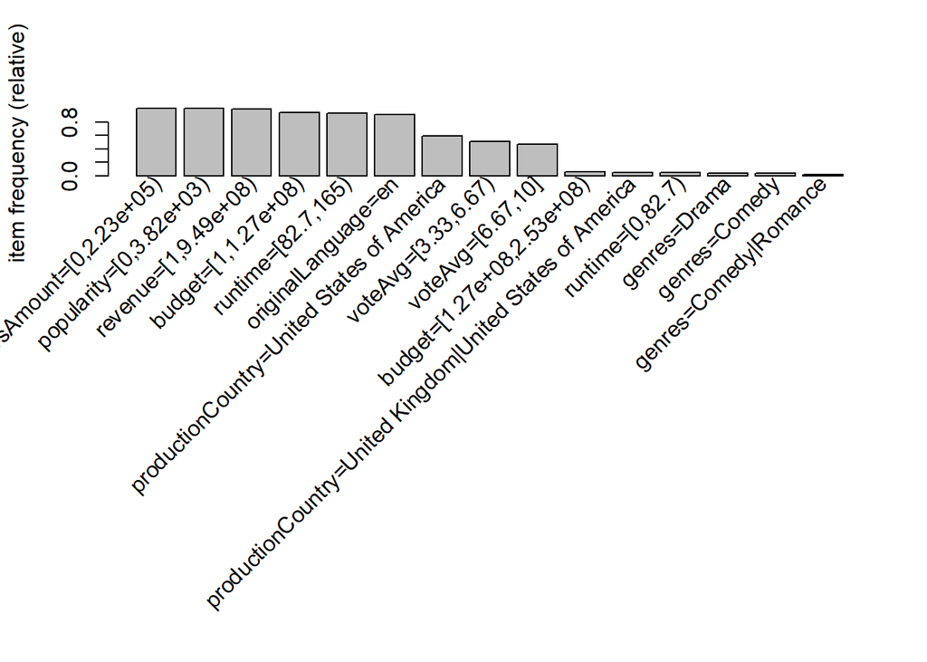

```r
#Revisar items más frecuentes

itemFrequencyPlot(movies_trans, topN = 15)
```

##Conclusión final El análisis de frecuencia de ítems mostró que el idioma inglés y la producción en Estados Unidos presentaban frecuencias extremadamente altas, generando reglas triviales y poco informativas. Por esta razón, se decidió eliminar dichas variables y volver a ejecutar el algoritmo A priori.

Estos resultados confirman que el desempeño financiero de una película está fuertemente relacionado con su inversión inicial, nivel de exposición pública y percepción de calidad.

## Aplicación de algoritmo

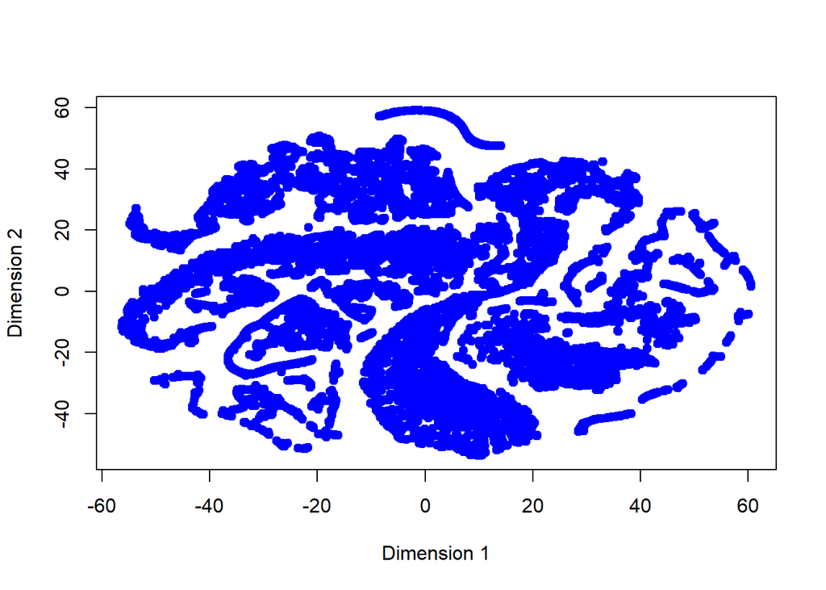

```r
clean_data <- na.omit(datos_pca)
tsne_model <- unique(clean_data)
tsne_thing <- Rtsne(tsne_model, dims = 2, perplexity = 30)

plot(tsne_thing$Y,
     pch = 19,
     col = "blue",
     xlab = "Dimension 1",
     ylab = "Dimension 2")
```

Se aplicó el algoritmo t-SNE para reducir la dimensionalidad del conjunto de datos y visualizar su estructura en dos dimensiones. Este método es útil porque permite representar datasets con muchas variables en un espacio más simple, preservando la similitud entre las observaciones.

En la visualización obtenida, cada punto representa una película del conjunto de datos. Se observan varias zonas donde los puntos se concentran, lo que sugiere la existencia de posibles agrupaciones de películas con características similares. Estas agrupaciones pueden estar relacionadas con variables como popularidad, duración, presupuesto o número de actores.

## Hallazgos y Conclusiones

El análisis realizado permitió identificar patrones claros dentro del conjunto de datos de películas. A partir del agrupamiento mediante K-means se distinguieron tres perfiles principales. El primero corresponde a producciones de alto presupuesto, elevada recaudación y gran popularidad, en su mayoría orientadas al mercado internacional y asociadas a géneros comerciales. Este grupo representa claramente el segmento de películas de alto impacto o blockbusters. El segundo perfil agrupa producciones de escala intermedia, con presupuestos y niveles de ingresos moderados, menor exposición mediática y mayor diversidad lingüística, lo cual sugiere un enfoque más regional o independiente. Finalmente, el tercer grupo está compuesto por producciones de bajo presupuesto y escasa recaudación, con niveles mínimos de popularidad, que podrían corresponder a proyectos de distribución limitada o cortometrajes.

El análisis de silueta indicó que, aunque la separación entre grupos no es perfecta, existe una estructura coherente en los datos. El método K-means presentó un desempeño ligeramente superior al clustering jerárquico, lo que justificó su selección como modelo definitivo para interpretar los segmentos identificados. En conjunto, el clustering revela que la escala financiera y el nivel de popularidad son factores determinantes en la segmentación del mercado cinematográfico.

Las reglas de asociación reforzaron la idea de que el éxito comercial no es aleatorio. Se identificaron patrones consistentes que muestran que películas con mayor presupuesto, elevada popularidad y buena calificación promedio presentan una probabilidad significativamente más alta de generar ingresos elevados. El lift cercano a tres en varias reglas indica que estas asociaciones ocurren casi tres veces más de lo esperado bajo independencia, lo que evidencia relaciones fuertes entre inversión, percepción pública y desempeño financiero. Al eliminar variables extremadamente frecuentes como el idioma inglés o la producción en Estados Unidos, las reglas obtenidas fueron menos numerosas pero más informativas, lo que permitió identificar relaciones más relevantes desde el punto de vista analítico.

La aplicación de t-SNE permitió visualizar la estructura del dataset en dos dimensiones, mostrando concentraciones de observaciones que sugieren la existencia de agrupaciones naturales. Aunque este método no se utilizó como técnica formal de segmentación, sirvió como herramienta exploratoria que respalda visualmente los resultados obtenidos mediante clustering.

En términos estratégicos, los resultados sugieren que el desempeño financiero de una película está estrechamente vinculado a la combinación de inversión inicial, visibilidad y percepción del público. Para CineVision Studios, esto implica que una correcta asignación de presupuesto acompañada de estrategias de promoción adecuadas puede influir significativamente en el retorno económico. Asimismo, mantener un portafolio equilibrado entre producciones de alto impacto y proyectos de escala intermedia podría reducir riesgo y estabilizar ingresos.